# RP13

聖心女子大学国際交流学科  
2024年秋学期

アジア経済研究所 伊藤成朗

「限界労働生産力は、資本の大きさと関係ない」という点がよくわかりませんでした。事例として、工業、製品を機械だけで生産し、人だけで、製品を箱詰めする工程とありましたが１つの機械での生産性＝一人の人間の生産性という認識であっているのでしょうか。

- 労働者一人あたりの生産性、機械一台あたりの生産性を議論しているのではありません
- 労働を微小時間だけ増やしたときの生産増分=労働の限界生産力、それが機械の多寡によってどう変わるかを議論しています
  - 労働の(手作業箱詰め)工程が機械の生産工程と完全に分かれているとき、機械が何台あろうが、労働時間を増やしたときの箱詰量の増加分は変わりません
  - このとき交差限界生産力はゼロです
  - 木材の切り出し工程を機械、成型工程を僅かな工具を使う櫛職人、完成した櫛の箱詰め工程を機械でする生産過程も交差限界生産力はゼロです
  - 例は少し現実離れしているかもしれません
- こうした生産過程は珍しいので現実離れしているように思えますが、数学で示した符号条件を現実に投影するとこういう状況だ、ということを示しました

貧しい家庭が、第１期目に教育投資を行うことができないことが第２期の賃金に影響して、さらにその子供が第１期目に十分な教育投資を行うことのできなくなってしまうというような負の連鎖が続いてしまう場合があると思いました。

- 貧困の罠、貧困の再生産といわれるものです
- 学期初に説明しましたが、貧困の再生産は「貧しいから投資が少ない」という漠然とした原因でした
- Baland and Robinsonモデルは「貧しいから信用制約下にあって投資が最適な水準よりも少ない」という明確な原因を示しています
  - このため、**どのような介入が必要か明確**という長所があります
  - より強調すべき: 最適化する個人を想定している→政府が学費融資をすると最適に人的資本投資に使う、という**自発的な反応を通じた厚生改善方法**を示すことができます
  - 貧困の罠の議論には最適な反応をする個人は含まれていません

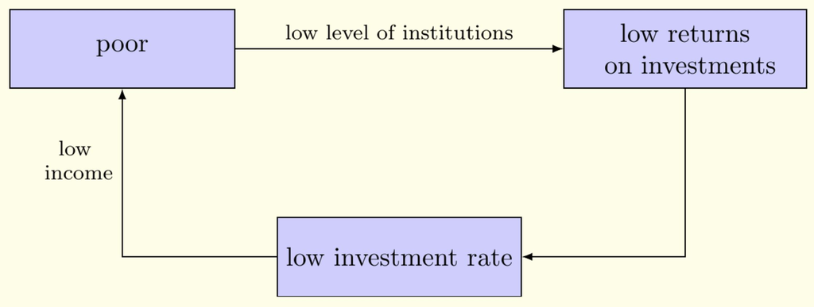

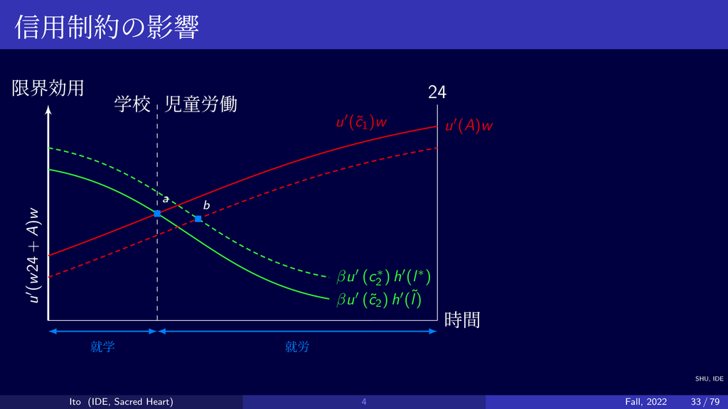

#### References

[figure not shown]

http://seiroito.github.io/SHLectures/lec_slides/2024/RP/RP11.html